# Analysis of wind (mechanosensoy) info comming into CX

```r
library(nat)
library(neuprintr)
library(tidyverse)
library(dplyr)
options(nat.plotengine = 'rgl')
```

```r
neuprint_login()
```

```r
# Get some custom functions
source("neuprintQueryUtils.R")
source("visualizeConnectivityTables.R")
source("inputOutputRegionsVis.R")

# To be able to use ? for accessing doc strings in custom functions, please install the "docstring" package. Alternatively use docstring(function)
library(docstring)
```

## Bodyid’s of neurons that are potentially involved

The propose pathway presented in Suver et al is Johnstons organs -> APN3/APN2 -> WPN

Here we will try to identify which neurons in the EM volume correspond to APN2, APN3 and WPN and illustrate a potential route toward the fly’s heading circuit.

```r
#APN3s (presynaptic of APN2s):
APN3ids = c(975289165, 1099073905, 1130458829)
#APN2s (postsynaptic of APN3s):
APN2ids = c(1539649574, 2096909915, 2096913987)

# get names
for (i in APN3ids) {
  print(neuprint_get_neuron_names(i))
  }
```

```
##               975289165
## "PDM14j_d_pct(PDM14)_R"
##              1099073905
## "PDM14j_d_pct(PDM14)_R"
##              1130458829
## "PDM14j_e_pct(PDM14)_R"
```

```r
for (i in APN2ids) {
  print(neuprint_get_neuron_names(i))
  }
```

```
##            1539649574
## "ADM06d_pct(ADM06)_R"
##                    2096909915
## "ADM06p_pct(aSP18b)(ADM06)_R"
##            2096913987
## "ADM06d_pct(ADM06)_R"
```

Get all neurons of the type described by the bodyids above

```r
APN3 = bind_rows(neuprint_search("PDM14j_d.*"),neuprint_search("PDM14j_e.*"))
APN2 = bind_rows(neuprint_search("ADM06d_.*"),neuprint_search("ADM06p_.*"))

APNBodies = c(APN3$bodyid,APN2$bodyid)
```

Also get body ID’s of putative downstream partners (these were identified in a shortest path analysis as shown later)

```r
# Putative WPN, based on morphology and connectivity: PDL27e
WPN = neuprint_search("PDL27e_pct.*")#5813047683)

# Partner of APN2 and putative WPN: ADM06b_b
ADM06b = neuprint_search("ADM06b_b.*")

# R1s
R1 = neuprint_search("R1_.*_R")
R1a = neuprint_search("R1_a.*_R")
R1b = neuprint_search("R1_b.*_R")
```

## Check if putative APN3s connect to APN2s

### Find where APN3 and 2 have inputs and outputs

```r
roi_Connect_rois = neuprint_get_roiInfo(APNBodies)
roi_Connect_rois =  mutate(roi_Connect_rois,
                        name = neuprint_get_meta(bodyid)$name,
                        type = neuprint_get_meta(bodyid)$type,
                        pre = neuprint_get_meta(bodyid)$pre,
                        post = neuprint_get_meta(bodyid)$post)


# rearrange so that information worth viewing is in first few columns
roi_Connect_rois = roi_Connect_rois[ , c(1,(ncol(roi_Connect_rois)-3):ncol(roi_Connect_rois),2:(ncol(roi_Connect_rois)-4)) ]
```

```r
# reorganize such that ROI, #pre and #post become variables
roi_Connect_rois_df = data.frame(bodyid = numeric(),
                              name = character(),
                              type = character(),
                              roi = character(),
                              prepost = character(),
                              count = numeric())

for (myroi in as.character(colnames(roi_Connect_rois))[6:(length(colnames(roi_Connect_rois)))]) {

  #if (length(as.character(filter(roisDf,value == unlist(strsplit(myroi, "[.]"))[1])$keyName)) == 1) next

  roiname = as.character(unlist(strsplit(myroi, "[.]"))[1])
  roiname = as.character(unlist(strsplit(roiname, "[(]"))[1])
  side = as.character(unlist(strsplit(myroi, "[(]"))[2])
  side = as.character(unlist(strsplit(side, "[)]"))[1])
  if (!grepl("[R,L]{1}", side)) {
    if ( !is.na(side) ) {roiname  = paste0(roiname, side) }
    side = "NA"
  }
  roi_Connect_roi = data.frame(bodyid = roi_Connect_rois$bodyid,
                            name = roi_Connect_rois$name,
                            type = roi_Connect_rois$type,
                            roi = roiname,
                            hemisphere = side,
                            prepost = unlist(strsplit(myroi, "[.]"))[2],
                            count = ( as.numeric(roi_Connect_rois[[myroi]]) ),
                            normcount = ( as.numeric(roi_Connect_rois[[myroi]]) / (roi_Connect_rois$pre + roi_Connect_rois$post) ) )
  roi_Connect_rois_df = bind_rows(roi_Connect_rois_df, roi_Connect_roi)
}

# remove ROIs that are collections of regions
exclue = c("PENP", "VMNP", "VLNP")
`%nin%` = Negate(`%in%`)
roi_Connect_rois_df = roi_Connect_rois_df %>% filter(roi %nin% exclue)
```

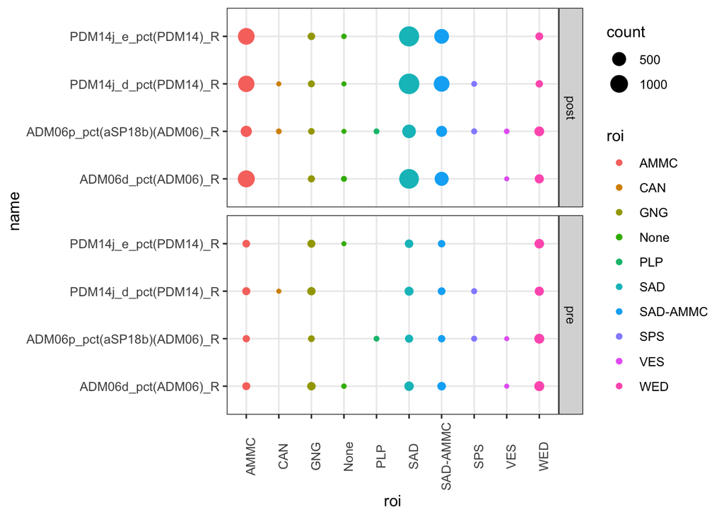

```r
ggplot(roi_Connect_rois_df, aes(x=roi, y=name, size=count)) +
  geom_point(aes(color=roi)) +
  facet_grid(vars(prepost) ) +
  theme_bw() + theme(axis.text.x = element_text(angle = 90))  + guides(fill=FALSE)
```

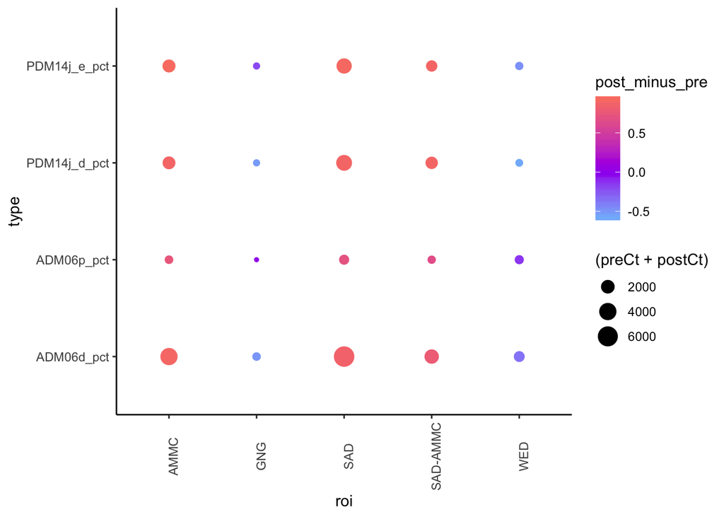

```r
ggsave("APNs_inputOutputRegions_perName.pdf", plot = last_plot(), device='pdf', path = "../neuprintR_analysis_plots/",
  scale = 1.5, width = 15, height = 10, units ="cm", dpi = 600, limitsize = TRUE)
cntCutoff = 20

preCoutnsPerRegionAndType =  roi_Connect_rois_df %>% group_by(type, roi) %>% filter(prepost == "pre") %>% summarise(preCt = sum(count, na.rm = TRUE))
postCoutnsPerRegionAndType =  roi_Connect_rois_df %>% group_by(type, roi) %>% filter(prepost == "post") %>% summarise(postCt = sum(count, na.rm = TRUE))

countsPerRegionAndType = full_join(preCoutnsPerRegionAndType, postCoutnsPerRegionAndType) %>%
  filter((preCt+postCt) > cntCutoff) %>%
  mutate(post_minus_pre = (postCt-preCt)/(preCt+postCt)) %>% na.omit()

ggplot(countsPerRegionAndType, aes(x=roi, y=type, size=(preCt+postCt))) +
  geom_point(aes(color=post_minus_pre)) + scale_color_gradient2(high = 'salmon', mid = "purple",
  low = 'cyan', midpoint = 0) +
  theme_classic() + theme(axis.text.x = element_text(angle = 90))  + guides(fill=FALSE)
```

```r
ggsave("APNs_inputOutputRatioRegions_perName.pdf", plot = last_plot(), device='pdf', path = "../neuprintR_analysis_plots/",
  scale = 1.5, width = 15, height = 10, units ="cm", dpi = 600, limitsize = TRUE)
```

### Visualize neurons

```r
APN3_skel = neuprint_read_neurons(APN3)
APN2_skel = neuprint_read_neurons(APN2)
```

For reference visualize some important partners

```r
WPN_skel = neuprint_read_neurons(WPN)
ADM06b_skel = neuprint_read_neurons(ADM06b)
R1_skel = neuprint_read_neurons(R1$bodyid[1])
```

Visualize the relevant ROIs

```r
AMMCmesh = neuprint_ROI_mesh("AMMC")
GNGmesh = neuprint_ROI_mesh("GNG")
# PENP does not appear to be a defined mesh (it's just a collection: SAD, AMMC, ...)
SADmesh = neuprint_ROI_mesh("SAD")
SADAMMCmesh = neuprint_ROI_mesh("SAD(-AMMC)")
# VLNP: collection of rois (AOTU, PLP, WED, ...)
WEDmesh = neuprint_ROI_mesh("WED(R)")
```

These meshes overlap heavily… SAD and WED seem to cover most of the putative interaction between APNs and WPNs

```r
# use https://www.w3schools.com/colors/colors_picker.asp to pick colors
#plot3d(AMMCmesh, alpha=0.2,  add=TRUE, col="#009999")
#plot3d(GNGmesh, alpha=0.2,  add=TRUE, col="#ff5050")
#plot3d(SADmesh, alpha=0.2,  add=TRUE, col="#ff99ff")
#plot3d(SADAMMCmesh, alpha=0.2,  add=TRUE, col="#ff9900")##66ffff")
#plot3d(WEDmesh, alpha=0.2,  add=TRUE, col="#ff9900")
```

```r
plot3d(APN3_skel, col="seagreen3")
plot3d(APN2_skel, col="cyan")
plot3d(WPN_skel, col="magenta")
plot3d(ADM06b_skel, col="orange")
plot3d(R1_skel, col="pink")
#plot3d(WEDmesh, alpha=0.2,  add=TRUE, col="#ff9900")
#plot3d(SADmesh, alpha=0.2,  add=TRUE, col="#ff99ff")
```

### Connectivity between APNs in primary ROIs (SAD, WED)

Primary ROIs were identified manually based on inspection of neuron arborization and mesh overlap. The number of relevant ROIs is easily overestimated, because meshes overlap.

### Connectivity matrix: APNs don’t directly talk to WPN

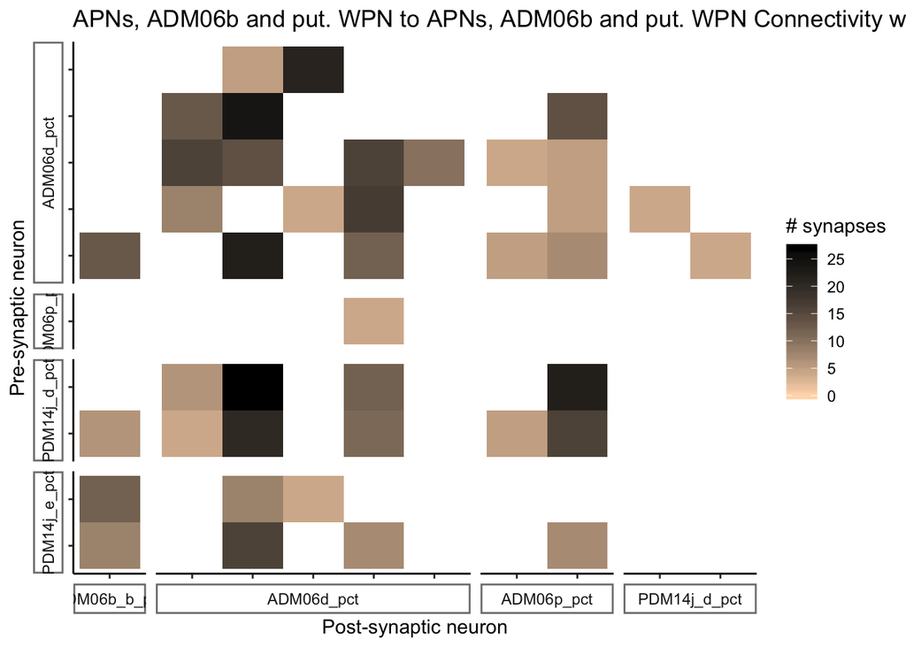

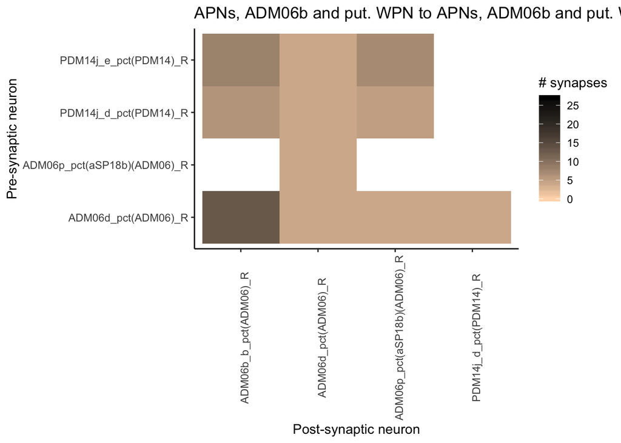

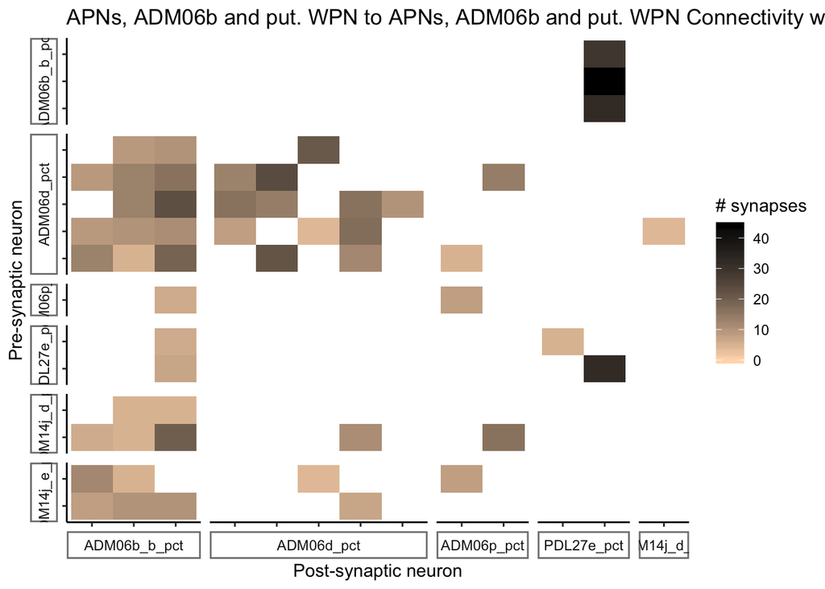

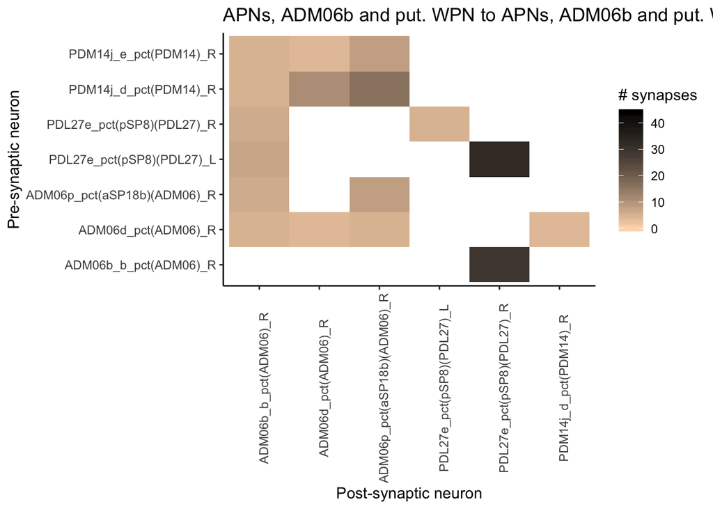

```r
preNeurons = c(APNBodies, ADM06b$bodyid, WPN$bodyid)
postNeurons = preNeurons
preName = "APNs, ADM06b and put. WPN"
postName = preName#"APN3, APN2"

for (slctROI in  c("SAD", "WED(R)")) {
  myConnections = getConnectionTable_forSubset(preNeurons,postNeurons, slctROI)

  ### Connectivity matrix  by name
  conMatPlot = plotConnectivityMatrix(myConnections, synapseCutOff = 3, byType = FALSE)
  conMatPlot = addMatrixPlotLabs(conMatPlot, preName,  postName, slctROI)
  conMatPlot = structureMatrixPlotByType(conMatPlot)
  print(conMatPlot)

   ggsave(paste0("APNs_connectivityMatrix_",slctROI,"_byName.pdf"), plot = last_plot(), device='pdf',
         path = "../neuprintR_analysis_plots/",
         scale = 1.5, width = 15, height = 15  , units ="cm", dpi = 600, limitsize = TRUE)

  ### Connectivity matrix by type
  conMatPlot = plotConnectivityMatrix(myConnections, synapseCutOff = 3, byType = TRUE)
  conMatPlot = addMatrixPlotLabs(conMatPlot, preName,  postName, slctROI)
  print(conMatPlot)

  ggsave(paste0("APNs_connectivityMatrix_",slctROI,"_byType.pdf"), plot = last_plot(), device='pdf',
         path = "../neuprintR_analysis_plots/",
         scale = 2, width = 13, height = 9, units ="cm", dpi = 600, limitsize = TRUE)
}
```

### Draw graph

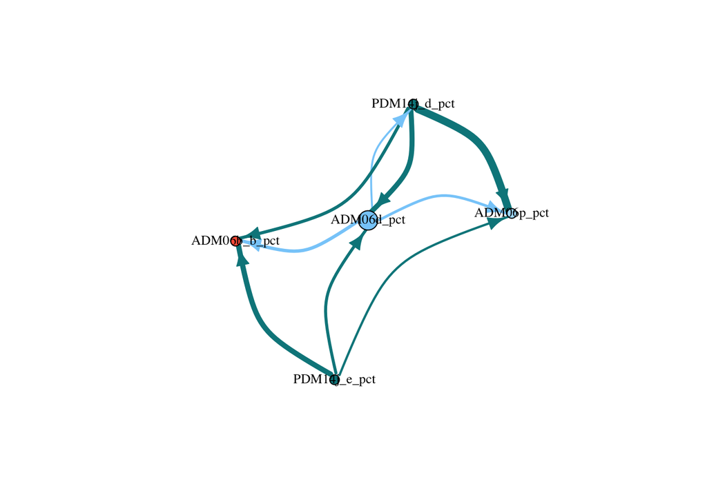

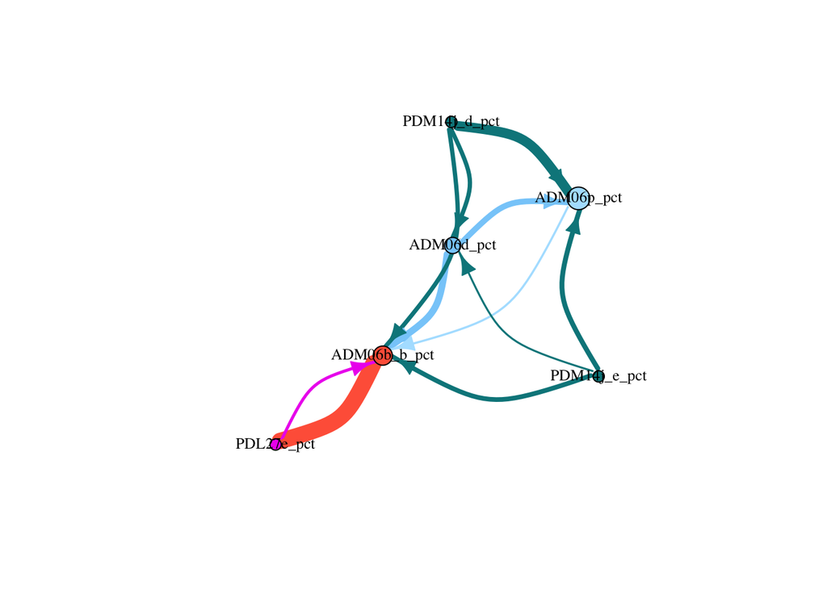

```r
require(igraph)
preIDs = bind_rows(APN3, APN2, ADM06b, WPN)
postIDs = preIDs

for (slctROI in  c("SAD", "WED(R)")) {
  myConnections = getConnectionTable_forSubset(preIDs$bodyid, postIDs$bodyid, slctROI)

  cutoff = 3

  # use connecitivity table created above
  typeCounts = full_join(preIDs, postIDs) %>% group_by(type) %>% count()

  #Reroganize to make graph with types instead of bodyids
  graphData = reorganizeGraphData(myConnections$partnerType,myConnections$type,myConnections$weight,cutoff)
  nodes = getGraphNodes(graphData)
  graphData_noSelf = getNoSelfGraphData(graphData)
  graphData_selfFB = getSelfFBGraphData(graphData)

  myGraph = constructConnectivityGraph(nodes, graphData_noSelf, graphData_selfFB, cutoff,7,1, 2)
  plot(myGraph,edge.curved=0.5, layout=layout_with_fr(myGraph),
       edge.color = customizeGraphEdges(myGraph)) # use 0.5 curved if edges overlap #edge.color=edge.col,

  #dev.off()
  dev.print(pdf, paste("../neuprintR_analysis_plots/connectivityGraphOfAPNs_in", slctROI,".pdf", sep=""),
            width=7, height=7)
}
```

## Viusualize paths to the CX

```r
pathFromAPN3_to_R1 = neuprint_get_shortest_paths(APN3$bodyid,R1$bodyid, weightT = 10)
```

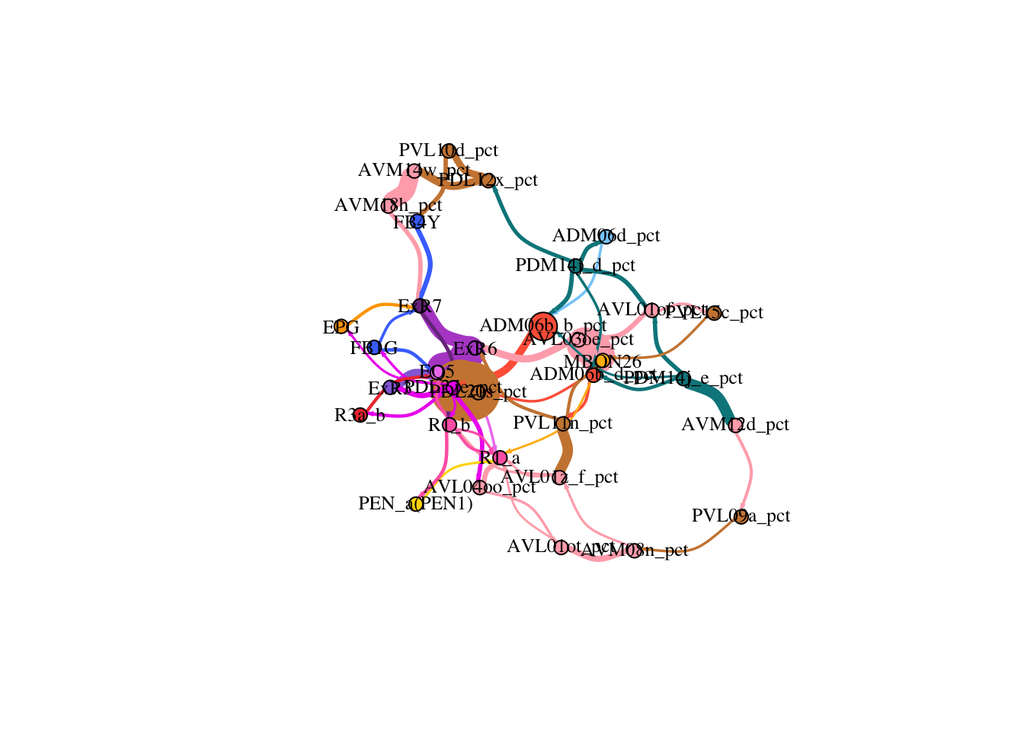

```r
cutoff = 3
pathFromAPN3_to_R1 = unique(pathFromAPN3_to_R1)
#Reroganize to make graph with types instead of bodyids
graphData = reorganizeGraphData(pathFromAPN3_to_R1$type.from,pathFromAPN3_to_R1$type.to,pathFromAPN3_to_R1$weight,cutoff)
nodes = getGraphNodes(graphData)
graphData_noSelf = getNoSelfGraphData(graphData)
graphData_selfFB = getSelfFBGraphData(graphData)
myGraph = constructConnectivityGraph(nodes, graphData_noSelf, graphData_selfFB, cutoff,7,.2, 7)
plot(myGraph,edge.curved=0.5, layout=layout_with_fr(myGraph),
     edge.color = customizeGraphEdges(myGraph)) # use 0.5 curved if edges overlap #edge.color=edge.col,
```

Filter pathways based on relative weights

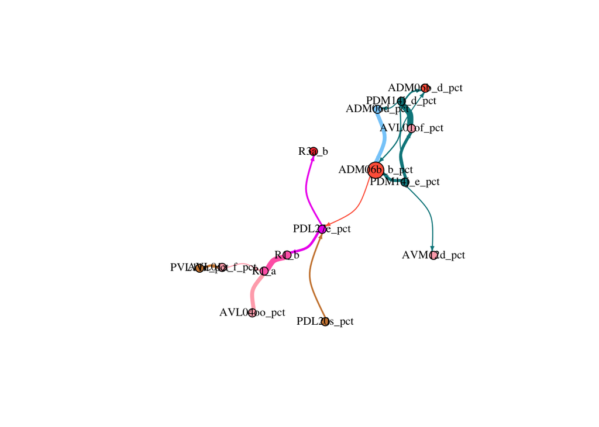

```r
cutoff = 3 #rel. weight (100%)
pathFromAPN3_to_R1 = unique(pathFromAPN3_to_R1)
nodeMeta = data.frame(bodyid = union(unique(pathFromAPN3_to_R1$from), unique(pathFromAPN3_to_R1$to)) )  %>%
                mutate(name = neuprint_get_meta(bodyid)$name,
                       type = neuprint_get_meta(bodyid)$type,
                       status = neuprint_get_meta(bodyid)$status,
                       pre = neuprint_get_meta(bodyid)$pre,
                       post = neuprint_get_meta(bodyid)$post)

# add relative weight based on total input to postsynaptic neuron
pathFromAPN3_to_R1 = pathFromAPN3_to_R1 %>% rowwise() %>%
  mutate(relWeight = 100*as.numeric(weight)/(filter(nodeMeta, nodeMeta$bodyid == to)$post)) %>% ungroup()

pathFromAPN3_to_R1_bytype = pathFromAPN3_to_R1 %>% group_by(type.to, type.from) %>%
  summarise(relWeight = sum(relWeight), depth = mean(depth))


#Reroganize to make graph with types instead of bodyids
graphData = reorganizeGraphData(pathFromAPN3_to_R1_bytype$type.from,
                                pathFromAPN3_to_R1_bytype$type.to,
                                pathFromAPN3_to_R1_bytype$relWeight,cutoff)
nodes = getGraphNodes(graphData)
graphData_noSelf = getNoSelfGraphData(graphData)
graphData_selfFB = getSelfFBGraphData(graphData)
myGraph = constructConnectivityGraph(nodes, graphData_noSelf, graphData_selfFB, cutoff,7,.3, 3)

# remove isolated nodes
dist.from.R1b <- distances(myGraph, v=V(myGraph)["R1_b"], to=V(myGraph), weights=NA) > 100
Isolated = which(dist.from.R1b)
myGraph_filt = delete.vertices(myGraph, Isolated)

plot(myGraph_filt,edge.curved=0.5, layout=layout_with_fr(myGraph_filt),
     edge.color = customizeGraphEdges(myGraph_filt)) # use 0.5 curved if edges overlap #edge.color=edge.col,
```

```r
dev.print(device = pdf, paste0("../neuprintR_analysis_plots/connectivityGraph_APN3_to_R1_minPostWeight",cutoff,".pdf"), width=12, height=12)
```

Start from APN2s

```r
pathFromAPN2_to_R1 = neuprint_get_shortest_paths(APN2$bodyid,R1$bodyid, weightT = 10)
```

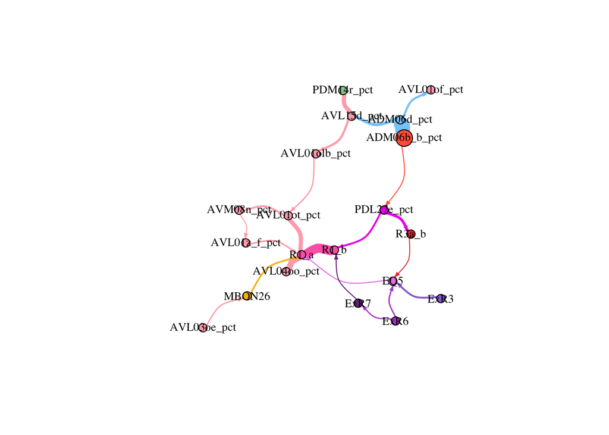

```r
cutoff = 2 # % of inputs

pathFromAPN2_to_R1 = unique(pathFromAPN2_to_R1)

nodeMeta = data.frame(bodyid = union(unique(pathFromAPN2_to_R1$from), unique(pathFromAPN2_to_R1$to)) )  %>%
                mutate(name = neuprint_get_meta(bodyid)$name,
                       type = neuprint_get_meta(bodyid)$type,
                       status = neuprint_get_meta(bodyid)$status,
                       pre = neuprint_get_meta(bodyid)$pre,
                       post = neuprint_get_meta(bodyid)$post)

# add relative weight based on total input to postsynaptic neuron
pathFromAPN2_to_R1 = pathFromAPN2_to_R1 %>% rowwise() %>%
  mutate(relWeight = 100*as.numeric(weight)/(filter(nodeMeta, nodeMeta$bodyid == to)$post)) %>% ungroup()

pathFromAPN2_to_R1_bytype = pathFromAPN2_to_R1 %>% group_by(type.to, type.from) %>%
  summarise(relWeight = sum(relWeight))

#Reroganize to make graph with types instead of bodyids
graphData = reorganizeGraphData(pathFromAPN2_to_R1_bytype$type.from,
                                pathFromAPN2_to_R1_bytype$type.to,
                                pathFromAPN2_to_R1_bytype$relWeight,cutoff)
nodes = getGraphNodes(graphData)
graphData_noSelf = getNoSelfGraphData(graphData)
graphData_selfFB = getSelfFBGraphData(graphData)
myGraph = constructConnectivityGraph(nodes, graphData_noSelf, graphData_selfFB, cutoff,7,.3, 2)

# remove isolated nodes
dist.from.R1b <- distances(myGraph, v=V(myGraph)["R1_b"], to=V(myGraph), weights=NA) > 100
Isolated = which(dist.from.R1b)
myGraph_filt = delete.vertices(myGraph, Isolated)

plot(myGraph_filt,edge.curved=0.5, layout=layout_with_fr(myGraph_filt),
     edge.color = customizeGraphEdges(myGraph_filt)) # use 0.5 curved if edges overlap #edge.color=edge.col,
```

```r
dev.print(pdf, paste0("../neuprintR_analysis_plots/connectivityGraph_APN2_to_R1_minPostWeight",cutoff,".pdf"), width=10, height=10)
```

Go all the way to EPGs

```r
EPG = neuprint_search("EPG.*_R.*")
pathFromAPN3_to_EPG = neuprint_get_shortest_paths(APN3$bodyid,EPG$bodyid, weightT = 10)
```

Filter pathways based on relative weights

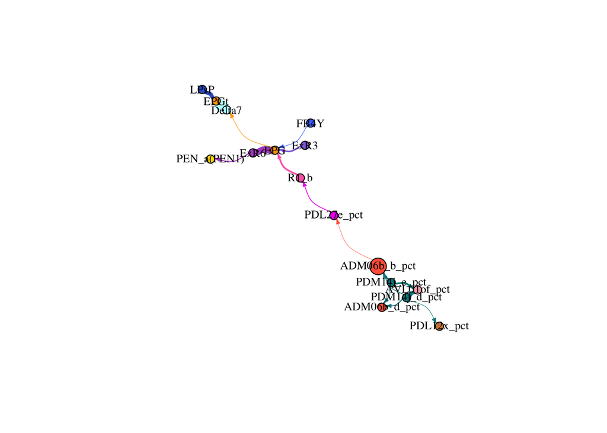

```r
source("visualizeConnectivityTables.R")
cutoff = 2# % of inputs

pathFromAPN3_to_EPG = unique(pathFromAPN3_to_EPG)

nodeMeta = data.frame(bodyid = union(unique(pathFromAPN3_to_EPG$from), unique(pathFromAPN3_to_EPG$to)) )  %>%
                mutate(name = neuprint_get_meta(bodyid)$name,
                       type = neuprint_get_meta(bodyid)$type,
                       status = neuprint_get_meta(bodyid)$status,
                       pre = neuprint_get_meta(bodyid)$pre,
                       post = neuprint_get_meta(bodyid)$post)

# add relative weight based on total input to postsynaptic neuron
pathFromAPN3_to_EPG = pathFromAPN3_to_EPG %>% rowwise() %>%
  mutate(relWeight = 100*as.numeric(weight)/(filter(nodeMeta, nodeMeta$bodyid == to)$post)) %>% ungroup()

pathFromAPN3_to_EPG_bytype = pathFromAPN3_to_EPG %>% group_by(type.from, type.to) %>%
  summarise(relWeight = sum(relWeight))

#Reroganize to make graph with types instead of bodyids
graphData = reorganizeGraphData(pathFromAPN3_to_EPG_bytype$type.from,
                                pathFromAPN3_to_EPG_bytype$type.to,
                                pathFromAPN3_to_EPG_bytype$relWeight,cutoff)
nodes = getGraphNodes(graphData)
graphData_noSelf = getNoSelfGraphData(graphData)
graphData_selfFB = getSelfFBGraphData(graphData)
myGraph = constructConnectivityGraph(nodes, graphData_noSelf, graphData_selfFB, cutoff,7,.3, 5)

# remove isolated nodes
dist.from.sink <- distances(myGraph, v=V(myGraph)["EPG"], to=V(myGraph), weights=NA) > 100
Isolated = which(dist.from.sink)
myGraph_filt = delete.vertices(myGraph, Isolated)

plot(myGraph_filt,edge.curved=0.5, layout=layout_with_fr(myGraph_filt),
     edge.color = customizeGraphEdges(myGraph_filt)) # use 0.5 curved if edges overlap #edge.color=edge.col,
```

```r
dev.print(pdf, paste0("../neuprintR_analysis_plots/connectivityGraph_APN3_to_EPG_minPostWeight",cutoff,".pdf"), width=10, height=10)
```